# Risk Factor Analysis

## Outcome Variable

**Outcome Variable:** pers_wast

## Predictor Variables

**Intervention Variable:** vagbrth

**Adjustment Set:**

- arm
- sex
- W_mage
- meducyrs
- feducyrs
- W_mhtcm
- W_mwtkg
- W_mbmi
- single
- brthmon
- W_parity
- delta_W_mage
- delta_meducyrs
- delta_feducyrs
- delta_W_mhtcm
- delta_W_mwtkg
- delta_W_mbmi
- delta_single
- delta_brthmon
- delta_W_parity

## Stratifying Variables

The analysis was stratified on these variable(s):

- agecat
- studyid
- country

## Data Summary

| agecat | studyid | country | vagbrth | pers_wast | n_cell | n |
| --- | --- | --- | --- | --- | --- | --- |
| 0-24 months | CMC-V-BCS-2002 | INDIA | 0 | 0 | 24 | 373 |
| 0-24 months | CMC-V-BCS-2002 | INDIA | 0 | 1 | 1 | 373 |
| 0-24 months | CMC-V-BCS-2002 | INDIA | 1 | 0 | 326 | 373 |
| 0-24 months | CMC-V-BCS-2002 | INDIA | 1 | 1 | 22 | 373 |
| 0-24 months | IRC | INDIA | 0 | 0 | 62 | 410 |
| 0-24 months | IRC | INDIA | 0 | 1 | 8 | 410 |
| 0-24 months | IRC | INDIA | 1 | 0 | 300 | 410 |
| 0-24 months | IRC | INDIA | 1 | 1 | 40 | 410 |
| 0-24 months | JiVitA-3 | BANGLADESH | 0 | 0 | 939 | 15765 |
| 0-24 months | JiVitA-3 | BANGLADESH | 0 | 1 | 57 | 15765 |
| 0-24 months | JiVitA-3 | BANGLADESH | 1 | 0 | 13931 | 15765 |
| 0-24 months | JiVitA-3 | BANGLADESH | 1 | 1 | 838 | 15765 |
| 0-24 months | JiVitA-4 | BANGLADESH | 0 | 0 | 341 | 4443 |
| 0-24 months | JiVitA-4 | BANGLADESH | 0 | 1 | 19 | 4443 |
| 0-24 months | JiVitA-4 | BANGLADESH | 1 | 0 | 3752 | 4443 |
| 0-24 months | JiVitA-4 | BANGLADESH | 1 | 1 | 331 | 4443 |
| 0-24 months | NIH-Crypto | BANGLADESH | 0 | 0 | 191 | 472 |
| 0-24 months | NIH-Crypto | BANGLADESH | 0 | 1 | 3 | 472 |
| 0-24 months | NIH-Crypto | BANGLADESH | 1 | 0 | 261 | 472 |
| 0-24 months | NIH-Crypto | BANGLADESH | 1 | 1 | 17 | 472 |
| 0-24 months | PROBIT | BELARUS | 0 | 0 | 1904 | 16583 |
| 0-24 months | PROBIT | BELARUS | 0 | 1 | 14 | 16583 |
| 0-24 months | PROBIT | BELARUS | 1 | 0 | 14545 | 16583 |
| 0-24 months | PROBIT | BELARUS | 1 | 1 | 120 | 16583 |
| 0-24 months | PROVIDE | BANGLADESH | 0 | 0 | 146 | 641 |
| 0-24 months | PROVIDE | BANGLADESH | 0 | 1 | 2 | 641 |
| 0-24 months | PROVIDE | BANGLADESH | 1 | 0 | 480 | 641 |
| 0-24 months | PROVIDE | BANGLADESH | 1 | 1 | 13 | 641 |
| 0-24 months | TanzaniaChild2 | TANZANIA, UNITED REPUBLIC OF | 0 | 0 | 192 | 2140 |
| 0-24 months | TanzaniaChild2 | TANZANIA, UNITED REPUBLIC OF | 0 | 1 | 6 | 2140 |
| 0-24 months | TanzaniaChild2 | TANZANIA, UNITED REPUBLIC OF | 1 | 0 | 1890 | 2140 |
| 0-24 months | TanzaniaChild2 | TANZANIA, UNITED REPUBLIC OF | 1 | 1 | 52 | 2140 |
| 0-24 months | ZVITAMBO | ZIMBABWE | 0 | 0 | 813 | 9449 |
| 0-24 months | ZVITAMBO | ZIMBABWE | 0 | 1 | 9 | 9449 |
| 0-24 months | ZVITAMBO | ZIMBABWE | 1 | 0 | 8472 | 9449 |
| 0-24 months | ZVITAMBO | ZIMBABWE | 1 | 1 | 155 | 9449 |

The following strata were considered:

- agecat: 0-24 months, studyid: CMC-V-BCS-2002, country: INDIA
- agecat: 0-24 months, studyid: IRC, country: INDIA
- agecat: 0-24 months, studyid: JiVitA-3, country: BANGLADESH
- agecat: 0-24 months, studyid: JiVitA-4, country: BANGLADESH
- agecat: 0-24 months, studyid: NIH-Crypto, country: BANGLADESH
- agecat: 0-24 months, studyid: PROBIT, country: BELARUS
- agecat: 0-24 months, studyid: PROVIDE, country: BANGLADESH
- agecat: 0-24 months, studyid: TanzaniaChild2, country: TANZANIA, UNITED REPUBLIC OF
- agecat: 0-24 months, studyid: ZVITAMBO, country: ZIMBABWE

### Dropped Strata

Some strata were dropped due to rare outcomes:

- agecat: 0-24 months, studyid: CMC-V-BCS-2002, country: INDIA
- agecat: 0-24 months, studyid: NIH-Crypto, country: BANGLADESH
- agecat: 0-24 months, studyid: PROVIDE, country: BANGLADESH

## Methods Detail

We're interested in the causal parameters $E[Y_a]$ for all values of $a \in \mathcal{A}$. These parameters represent the mean outcome if, possibly contrary to fact, we intervened to set all units to have $A=a$. Under the randomization and positivity assumptions, these are identified by the statistical parameters $\psi_a=E_W[E_{Y|A,W}(Y|A=a,W)]$. In addition, we're interested in the mean of $Y$, $E[Y]$ under no intervention (the observed mean). We will estimate these parameters by using SuperLearner to fit the relevant likelihood factors -- $E_{Y|A,W}(Y|A=a,W)$ and $p(A=a|W)$, and then updating our likelihood fit using a joint TMLE.

For unadjusted analyses ($W=\{\}$), initial likelihoods were estimated using Lrnr_glm to estimate the simple $E(Y|A)$ and Lrnr_mean to estimate $p(A)$. For adjusted analyses, a small library containing Lrnr_glmnet, Lrnr_xgboost, and Lrnr_mean was used.

Having estimated these parameters, we will then use the delta method to estimate relative risks and attributable risks relative to a prespecified baseline level of $A$.

# Results Detail

## Results Plots

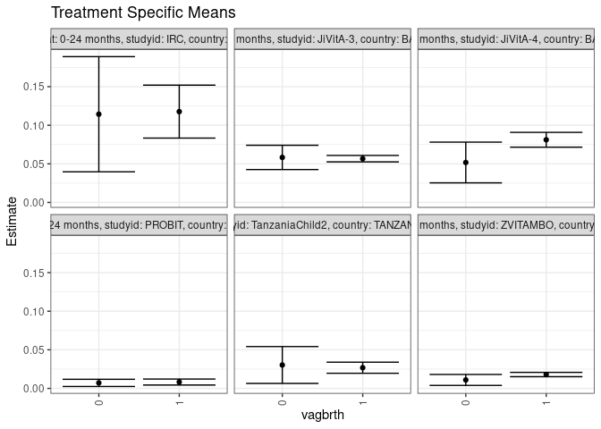

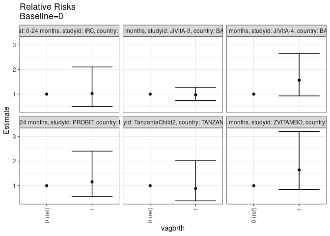

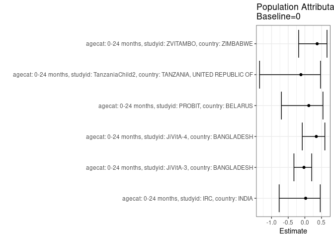

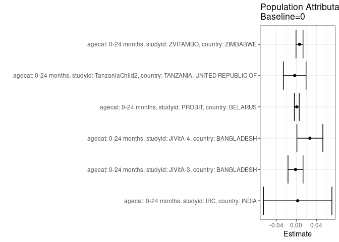

## Results Table

### Parameter: TSM

| agecat | studyid | country | intervention_level | baseline_level | estimate | ci_lower | ci_upper |
| --- | --- | --- | --- | --- | --- | --- | --- |
| 0-24 months | IRC | INDIA | 0 | NA | 0.1142857 | 0.0396628 | 0.1889086 |
| 0-24 months | IRC | INDIA | 1 | NA | 0.1176471 | 0.0833584 | 0.1519357 |
| 0-24 months | JiVitA-3 | BANGLADESH | 0 | NA | 0.0583113 | 0.0425796 | 0.0740430 |
| 0-24 months | JiVitA-3 | BANGLADESH | 1 | NA | 0.0566856 | 0.0524978 | 0.0608734 |
| 0-24 months | JiVitA-4 | BANGLADESH | 0 | NA | 0.0517184 | 0.0253342 | 0.0781027 |
| 0-24 months | JiVitA-4 | BANGLADESH | 1 | NA | 0.0811592 | 0.0715712 | 0.0907471 |
| 0-24 months | PROBIT | BELARUS | 0 | NA | 0.0071303 | 0.0024741 | 0.0117865 |
| 0-24 months | PROBIT | BELARUS | 1 | NA | 0.0082324 | 0.0043556 | 0.0121091 |
| 0-24 months | TanzaniaChild2 | TANZANIA, UNITED REPUBLIC OF | 0 | NA | 0.0303030 | 0.0064206 | 0.0541854 |
| 0-24 months | TanzaniaChild2 | TANZANIA, UNITED REPUBLIC OF | 1 | NA | 0.0267765 | 0.0195951 | 0.0339579 |
| 0-24 months | ZVITAMBO | ZIMBABWE | 0 | NA | 0.0109489 | 0.0038346 | 0.0180632 |
| 0-24 months | ZVITAMBO | ZIMBABWE | 1 | NA | 0.0179668 | 0.0151637 | 0.0207700 |

### Parameter: E(Y)

| agecat | studyid | country | intervention_level | baseline_level | estimate | ci_lower | ci_upper |
| --- | --- | --- | --- | --- | --- | --- | --- |
| 0-24 months | IRC | INDIA | NA | NA | 0.1170732 | 0.0859146 | 0.1482317 |
| 0-24 months | JiVitA-3 | BANGLADESH | NA | NA | 0.0567713 | 0.0526559 | 0.0608868 |
| 0-24 months | JiVitA-4 | BANGLADESH | NA | NA | 0.0787756 | 0.0696990 | 0.0878522 |
| 0-24 months | PROBIT | BELARUS | NA | NA | 0.0080806 | 0.0045539 | 0.0116073 |
| 0-24 months | TanzaniaChild2 | TANZANIA, UNITED REPUBLIC OF | NA | NA | 0.0271028 | 0.0202213 | 0.0339843 |
| 0-24 months | ZVITAMBO | ZIMBABWE | NA | NA | 0.0173563 | 0.0147230 | 0.0199897 |

### Parameter: RR

| agecat | studyid | country | intervention_level | baseline_level | estimate | ci_lower | ci_upper |
| --- | --- | --- | --- | --- | --- | --- | --- |
| 0-24 months | IRC | INDIA | 0 | 0 | 1.0000000 | 1.0000000 | 1.000000 |
| 0-24 months | IRC | INDIA | 1 | 0 | 1.0294118 | 0.5035574 | 2.104405 |
| 0-24 months | JiVitA-3 | BANGLADESH | 0 | 0 | 1.0000000 | 1.0000000 | 1.000000 |
| 0-24 months | JiVitA-3 | BANGLADESH | 1 | 0 | 0.9721200 | 0.7397471 | 1.277487 |
| 0-24 months | JiVitA-4 | BANGLADESH | 0 | 0 | 1.0000000 | 1.0000000 | 1.000000 |
| 0-24 months | JiVitA-4 | BANGLADESH | 1 | 0 | 1.5692498 | 0.9286609 | 2.651716 |
| 0-24 months | PROBIT | BELARUS | 0 | 0 | 1.0000000 | 1.0000000 | 1.000000 |
| 0-24 months | PROBIT | BELARUS | 1 | 0 | 1.1545636 | 0.5550771 | 2.401499 |
| 0-24 months | TanzaniaChild2 | TANZANIA, UNITED REPUBLIC OF | 0 | 0 | 1.0000000 | 1.0000000 | 1.000000 |
| 0-24 months | TanzaniaChild2 | TANZANIA, UNITED REPUBLIC OF | 1 | 0 | 0.8836251 | 0.3843408 | 2.031513 |
| 0-24 months | ZVITAMBO | ZIMBABWE | 0 | 0 | 1.0000000 | 1.0000000 | 1.000000 |
| 0-24 months | ZVITAMBO | ZIMBABWE | 1 | 0 | 1.6409721 | 0.8411810 | 3.201201 |

### Parameter: PAR

| agecat | studyid | country | intervention_level | baseline_level | estimate | ci_lower | ci_upper |
| --- | --- | --- | --- | --- | --- | --- | --- |
| 0-24 months | IRC | INDIA | 0 | NA | 0.0027875 | -0.0653152 | 0.0708901 |
| 0-24 months | JiVitA-3 | BANGLADESH | 0 | NA | -0.0015400 | -0.0165079 | 0.0134280 |
| 0-24 months | JiVitA-4 | BANGLADESH | 0 | NA | 0.0270572 | 0.0012316 | 0.0528827 |
| 0-24 months | PROBIT | BELARUS | 0 | NA | 0.0009503 | -0.0038987 | 0.0057993 |
| 0-24 months | TanzaniaChild2 | TANZANIA, UNITED REPUBLIC OF | 0 | NA | -0.0032002 | -0.0258316 | 0.0194312 |
| 0-24 months | ZVITAMBO | ZIMBABWE | 0 | NA | 0.0064074 | -0.0005741 | 0.0133889 |

### Parameter: PAF

| agecat | studyid | country | intervention_level | baseline_level | estimate | ci_lower | ci_upper |
| --- | --- | --- | --- | --- | --- | --- | --- |
| 0-24 months | IRC | INDIA | 0 | NA | 0.0238095 | -0.7714072 | 0.4620391 |
| 0-24 months | JiVitA-3 | BANGLADESH | 0 | NA | -0.0271262 | -0.3275845 | 0.2053326 |
| 0-24 months | JiVitA-4 | BANGLADESH | 0 | NA | 0.3434713 | -0.0782574 | 0.6002533 |
| 0-24 months | PROBIT | BELARUS | 0 | NA | 0.1176010 | -0.7037072 | 0.5429801 |
| 0-24 months | TanzaniaChild2 | TANZANIA, UNITED REPUBLIC OF | 0 | NA | -0.1180773 | -1.3584262 | 0.4699445 |
| 0-24 months | ZVITAMBO | ZIMBABWE | 0 | NA | 0.3691695 | -0.1863150 | 0.6645519 |